# Lecture 4: Graphics part 2

CPECGM2

### Agenda

Here are the libraries we will need

```r
library(plyr)
library(ggplot2)
library(reshape2)
```

### Customizing appearances

Make a table of avg `cty` mileage:

```r
mpg.means = ddply(mpg, 'class', summarize, avg.cty = mean(cty))
mpg.means
```

```
       class  avg.cty
1    2seater 15.40000
2    compact 20.12766
3    midsize 18.75610
4    minivan 15.81818
5     pickup 13.00000
6 subcompact 20.37143
7        suv 13.50000
```

Our basic plot:

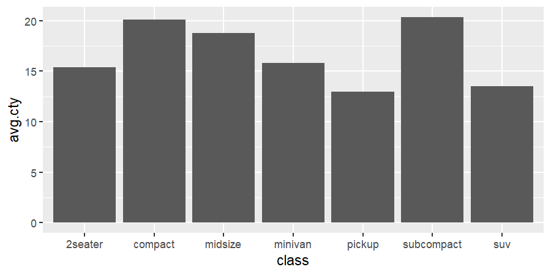

```r
ggplot(data = mpg.means, mapping=aes(x=class, y = avg.cty, group=1)) + geom_bar(stat='identity')
```

### Reording the factor levels

Bad: `class` levels are ordered alphabetically by default

`reorder()`: reorders the levels of a factor

```r
# check the order of the levels
levels(mpg.means$class)
```

```r
# the reorder command changes the ordering of the vehicle classes
mpg.means$class = with(mpg.means, reorder(class, avg.cty, mean))
# what is the new order of the levels?
levels(mpg.means$class)
```

```
[1] "pickup"     "suv"        "2seater"    "minivan"    "midsize"
[6] "compact"    "subcompact"
```

Here are the arguments for `reorder()`:

| argument of `reorder` | description |
| --- | --- |
| `x` (first argument) | The vector that you want reordered |
| `X` (second argument) | A numeric vector that determines the ordering of `x` |
| `FUN=mean` (third argument) | If multiple values in `X` are associated with a single factor level, then take their average (or `max` or `min` if you prefer) |

Using `reorder()` makes the plot easier to read:

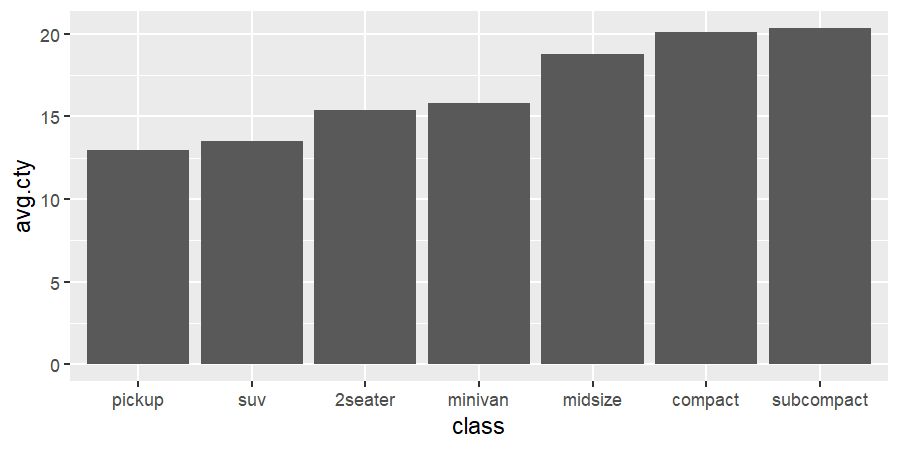

```r
mpg.plot = ggplot(data = mpg.means, mapping=aes(x=class, y = avg.cty, group=1)) + geom_bar(stat='identity')
mpg.plot
```

### Manually ordering and removing categorical levels in a plot

`scale_x_discrete()`: manually choose which levels to display and their ordering (for discrete variables).

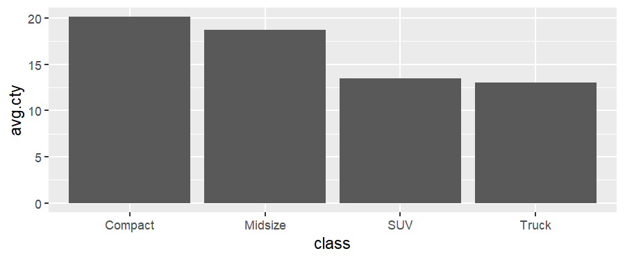

```r
# Select 4 classes and their ordering
mpg.plot + scale_x_discrete(limits = c('compact', 'midsize', 'suv', 'pickup'), labels = c('Compact', 'Midsize', 'SUV', 'Truck'))
```

`scale_y_discrete()`: same thing but for a discrete y-axis.

### Labeling the axes and title

Use `labs()`:

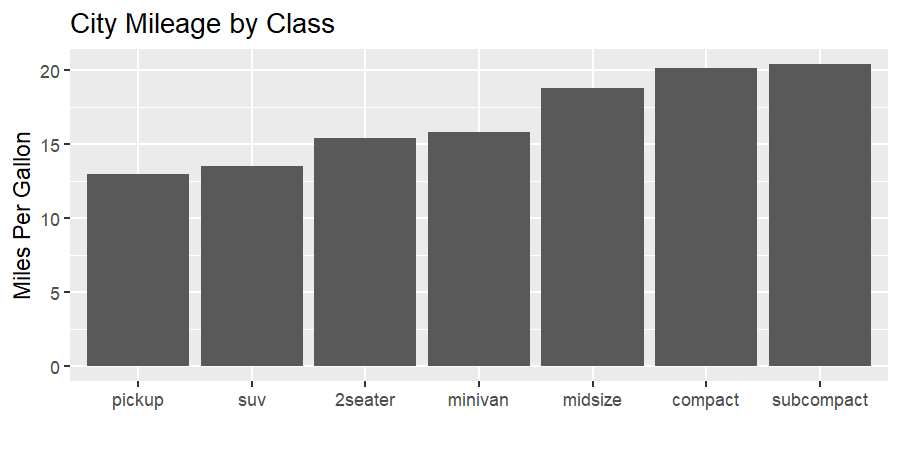

```r
mpg.plot = mpg.plot + labs(x = '', y = 'Miles Per Gallon', title='City Mileage by Class')
mpg.plot
```

For long labels, we can use the special character `\n` to denote a line break:

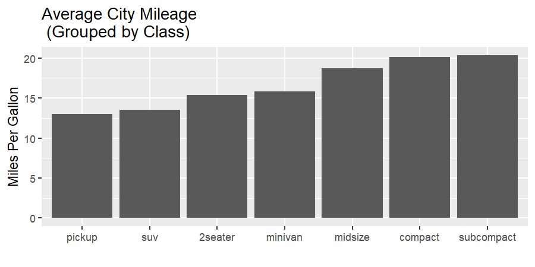

```r
mpg.plot + labs(title='Average City Mileage \n (Grouped by Class)')
```

### Changing the overall font

`theme()`: controls a lot of things, including text. You should never have tiny unreadable text in a slideshow!

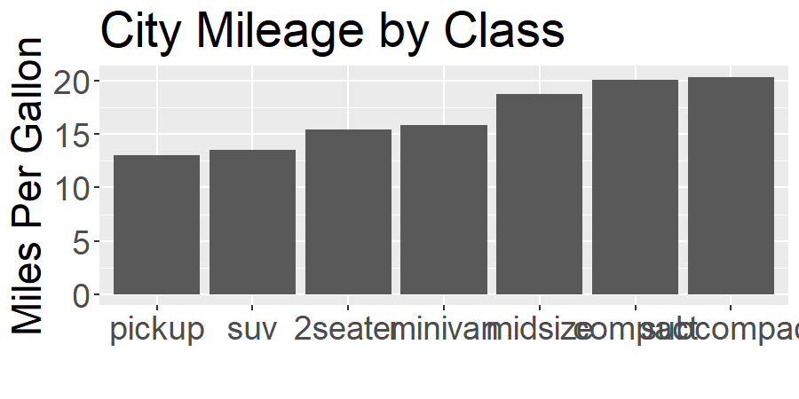

```r
# change the font size to 22
mpg.plot + theme(text = element_text(size=22))
```

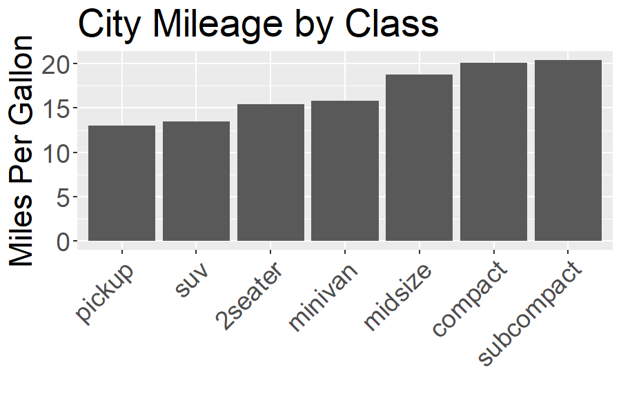

```r
# change the font size to 22, and rotate the x axis categories
mpg.plot + theme(text = element_text(size=22), axis.text.x = element_text(angle=45, vjust=1, hjust=1))
```

`vjust` and `hjust`: vertical and horizontal justification

### Using `cut` to create new discrete variables

Bar charts and facets require discrete variables.

If you want to facet a continuous variable, use `cut` or `cut_number` to create discrete levels.

```r
# make discrete levels from hwy
mpg = mutate(mpg, hwy.cat = cut_number(hwy, n = 4))
# reorder the classes for nicer plot
mpg$class = with(mpg, reorder(class, hwy, mean))
# how many records in each class, for different hwy levels?
ggplot(data = mpg, mapping=aes(x = class)) + geom_bar() + facet_wrap('hwy.cat', ncol=1)
```

Here is the plot:

[figure not shown]

### Drawing errorbars

`geom_errorbar()` takes mappings `x`, `ymin`, and `ymax`:

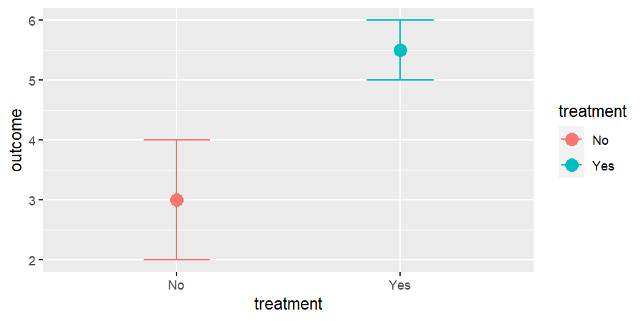

```r
# This plot says: treatment makes something better!
ggplot(data = small.df, mapping = aes(x = treatment, ymin = ymin, ymax = ymax, color = treatment)) + geom_errorbar(width=.3) + geom_point(mapping=aes(y=outcome), size=4)
```

### Computing errorbars

Here are three different functions for computing error bars:

- `mean_cl_normal()`: computes 95% CIs using a normal approximation (equal to t-test)
- `mean_cl_boot()`: 95% CIs using a bootstrap
- `mean_se()`: computes standard errors using normal approximation

[output not shown]